# 21MIS1172_Lab_Assignment_Single and Complete Link

### Complete Link Clustering

```python
def complete_linkage(dist_matrix):
    n = len(dist_matrix)
    while n > 1:
        min_val = float('inf')
        min_index = None
        for i in range(n):
            for j in range(i+1, n):
                if dist_matrix.iloc[i, j] < min_val and dist_matrix.index[i] != min_index:
                    min_val = dist_matrix.iloc[i, j]
                    min_index = (i, j)
        if min_val == float('inf'):
            break
        i, j = min_index
        cluster1, cluster2 = dist_matrix.index[i], dist_matrix.columns[j]
        print(f'Merging clusters {cluster1} and {cluster2} with distance {min_val}')
        new_cluster = f'({cluster1},{cluster2})'
        dist_matrix[new_cluster] = dist_matrix[[cluster1, cluster2]].max(axis=1)
        dist_matrix.loc[new_cluster] = dist_matrix.loc[[cluster1, cluster2]].max(axis=0)
        dist_matrix = dist_matrix.drop([cluster1, cluster2], axis=0)
        dist_matrix = dist_matrix.drop([cluster1, cluster2], axis=1)
        n -= 1
        print(dist_matrix)
        print("")
print("Complete-Link Clustering:")
complete_linkage(dist.copy())
```

```
Complete-Link Clustering:
Merging clusters P1 and P3 with distance 0.03605551275463991
Point          P2        P4        P5        P6        P7        P8        P9  \
Point
P2       0.000000  0.522015  0.388330  0.845340  0.317648  0.258070  0.141421
P4       0.522015  0.000000  0.694046  0.626498  0.572014  0.640703  0.398121
P5       0.388330  0.694046  0.000000  0.670075  0.122066  0.633246  0.480416
P6       0.845340  0.626498  0.670075  0.000000  0.610000  1.081665  0.814002
P7       0.317648  0.572014  0.122066  0.610000  0.000000  0.574543  0.383275
P8       0.258070  0.640703  0.633246  1.081665  0.574543  0.000000  0.273130
P9       0.141421  0.398121  0.480416  0.814002  0.383275  0.273130  0.000000
P10      0.152643  0.628013  0.505668  0.997647  0.456070  0.131529  0.230868
P11      0.813019  0.641950  0.612046  0.072111  0.560446  1.056030  0.793095
P12      0.429418  0.111803  0.652993  0.696419  0.532259  0.530094  0.297321
P13      0.671193  0.228035  0.724224  0.437379  0.610574  0.837437  0.573149
P14      0.174642  0.696419  0.392046  0.964624  0.374433  0.280179  0.310644
P15      0.405216  0.306757  0.411096  0.456070  0.294109  0.627694  0.358050
(P1,P3)  0.144222  0.648845  0.341321  0.901388  0.314006  0.337343  0.284253

Point         P10       P11       P12       P13       P14       P15   (P1,P3)
Point
P2       0.152643  0.813019  0.429418  0.671193  0.174642  0.405216  0.144222
P4       0.628013  0.641950  0.111803  0.228035  0.696419  0.306757  0.648845
P5       0.505668  0.612046  0.652993  0.724224  0.392046  0.411096  0.341321
P6       0.997647  0.072111  0.696419  0.437379  0.964624  0.456070  0.901388
P7       0.456070  0.560446  0.532259  0.610574  0.374433  0.294109  0.314006
P8       0.131529  1.056030  0.530094  0.837437  0.280179  0.627694  0.337343
P9       0.230868  0.793095  0.297321  0.573149  0.310644  0.358050  0.284253
P10      0.000000  0.965660  0.523927  0.800999  0.152971  0.553624  0.206155
P11      0.965660  0.000000  0.702140  0.470425  0.923093  0.438634  0.860058
P12      0.523927  0.702140  0.000000  0.331210  0.603738  0.310161  0.560803
P13      0.800999  0.470425  0.331210  0.000000  0.837257  0.317648  0.780897
P14      0.152971  0.923093  0.603738  0.837257  0.000000  0.551453  0.094340
P15      0.553624  0.438634  0.310161  0.317648  0.551453  0.000000  0.490408
(P1,P3)  0.206155  0.860058  0.560803  0.780897  0.094340  0.490408  0.036056

Merging clusters P6 and P11 with distance 0.07211102550927972
Point           P2        P4        P5        P7        P8        P9  \
Point
P2        0.000000  0.522015  0.388330  0.317648  0.258070  0.141421
```

[output cut: 249 more lines]

```
Merging clusters (P6,P11) and (P13,(P15,(P4,P12))) with distance 0.7021395872616784
Point                                         ((P5,P7),((P14,(P1,P3)),((P8,P10),(P2,P9))))  \
Point
((P5,P7),((P14,(P1,P3)),((P8,P10),(P2,P9))))                                      0.633246
((P6,P11),(P13,(P15,(P4,P12))))                                                   1.081665

Point                                         ((P6,P11),(P13,(P15,(P4,P12))))
Point
((P5,P7),((P14,(P1,P3)),((P8,P10),(P2,P9))))                         1.081665
((P6,P11),(P13,(P15,(P4,P12))))                                      0.702140

Merging clusters ((P5,P7),((P14,(P1,P3)),((P8,P10),(P2,P9)))) and ((P6,P11),(P13,(P15,(P4,P12)))) with distance 1.0816653826391969
Point                                               (((P5,P7),((P14,(P1,P3)),((P8,P10),(P2,P9)))),((P6,P11),(P13,(P15,(P4,P12)))))
Point
(((P5,P7),((P14,(P1,P3)),((P8,P10),(P2,P9)))),(...                                           1.081665
```

As indicated in the output, the points (P1,P3) is having the the least distance of all with 0.036055, so initially we'll merge those two points together considering the least distance between them, to cluster together. Then the next least distance of all the maximum distances is between P6 and P11 with distance 0.072111 , so we'll merge those two clusters. Similarly, calculating the least distance between each points and clusters and merging them based on the maximum distance between the neighbouring clusters is called Complete Linkage Clustering. This loop continues until all data points are clustered, revealing patterns in the data.

#### Dendrogram for Complete Linkage

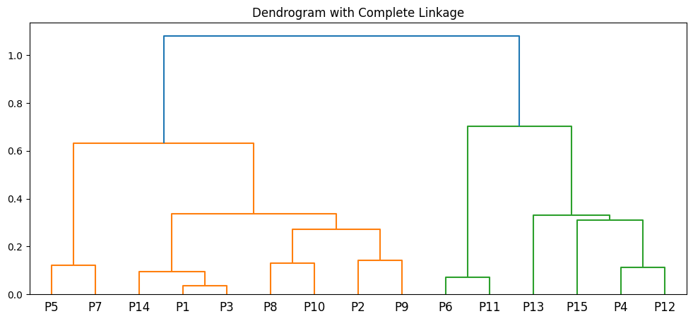

```python
plt.figure(figsize=(12,5))
plt.title("Dendrogram with Complete Linkage")
dend = shc.dendrogram(shc.linkage(df[['a', 'b']], method='complete'), labels=df.index)
```